# STAT 421 Assignment #2

STAT 421 Assignment #2 Duncan Gates 08 October, 2020

## Problem 2.54

There are ${8 \choose 4}$ ways to choose 4 students from the 8 overall students.

There are $3 \choose 2$ ways to choose 2 undergraduates and ${5 \choose 2}$ graduate student selections possible if two undergraduates are selected.

So we have $\frac{{3 \choose 2}{5 \choose 2}}{8 \choose 4}$ as the probability that two undergraduates will be among the four chosen.

$\frac{{3 \choose 2}{5 \choose 2}}{8 \choose 4} = \frac{3*10}{70}$

$\boxed{\frac{3}{7}}$

## Problem 2.64

The numbers 1,2,3,4,5, and 6 can be arranged in 6! ways, and if the die is tossed 6 times then the number of samples will be $6^6$

Therefore we have,

$(\frac{6!}{6})^6=\frac{720}{46656}=0.0154$

## Problem 2.72

**a.** Are the events A and M independent?

We have $P(A)=0.6$ and $P(M) = 0.4$, $P(\overline{A})=0.4$, and $P(\overline{M}) = 0.6$

The tables gives that $P(A \cap M) = 0.24$

Events A and M are independent if $P(A/M) = P(A)$, $P(M/A)=P(M)$, and $P(A \cap M) = P(A)P(M)$

For $P(A / M) = \frac{P(A \cap M)}{P(M)}$

We have $= \frac{0.24}{0.4}$

$= 0.6 = P(A)$

For $P(M/A) = \frac{P(M \cap A)}{P(A)}$

We have $\frac{0.24}{0.6}$

$= 0.4 = P(M)$

For $P(A \cap M)= P(A)P(M)$

We have $=0.6*0.4$

$= \boxed{0.24}$

Therefore all conditions of independence are satisfied and events A and M are independent.

**b.** Are the events $\overline{A}$ and F independent?

The events $\overline{A}$ and F are independent if $P(\overline{A}/F) = P(\overline{A})$, $P(F/\overline{A})=P(F)$, and $P(\overline{A} \cap F) = P(\overline{A})P(F)$

For $P(\overline{A}/F) = P(\overline{A})$

We have $=\frac{0.24}{0.6}$

$= 0.4 = P(\overline{A})$

For $P(F/\overline{A})=P(F)$

We have $\frac{0.24}{0.4}$

$=0.6 = P(F)$

For $P(\overline{A} \cap F) = P(\overline{A})P(F)$

We have $0.4*0.6$

$= 0.24$

Therefore all three conditions are satisfied and events $\overline{A}$ AND F are independent.

## Problem 2.80

Given $A \subset B$ and that $P(A)>0$ and $P(B)>0$

Let $A \subset B$, then by probability we have, $P(A) < P(B)$

${A \cap B}$ and $A \cup B = B$

$P(A \cap B) = P(A)$ and

$P(A \cup B) = P(B)$

$P(B|A)=\frac{A \cap B}{P(A)}$

$= \frac{P(A)}{P(A)}$ (since $A \subset B$, $A \cap B = A$ and $P(A \cap B) = P(A))$

$=1$

Therefore, $P(B|A) = 1$

$P(A|B)=\frac{P(A \cap B)}{P(B)}$

= $\frac{P(A)}{P(B)}$ (since $A \subset B, A \cap B=A$ and $P(A \cap B)=P(A))$

Therefore $\boxed{P(A | B) = \frac{P(A)}{P(B)}}$

## Problem 2.88

**a.**

It is possible that $P(A \cap B) = 0.1$, the intersection of events has to be at least 0 and at most 0.3. Therefore it is possible that it will be 0.1 since $0<0.01<0.3$.

**b.**

The smallest possible value for the intersection of events A and B is 0 since the sets could be disjoint.

**c.**

It is not possible that $P(A \cap B)=0.7$ since this is greater than the probability of either A or B, $0 < 0.6 < 0.7$

**d.**

The largest possible value of $P(A \cap B)$ is 0.3, since the intersection of events A and B is the subset of individual events A and B. Therefore the maximum value is equal to the lowest probability of individual events.

## Problem 2.98

The probability that current will flow in the series system is

Let $E_1$ = Relay 1 is activated, $E_2$ = Relay 2 is activated

Then $P(E_1)=0.9$, $P(E_2) = 0.9$

and $P(\overline{E_1}) = 0.1$, $P(\overline{E_2}) = 0.1$

$P(E_1)*P(E_2)$

$(0.9)(0.9)$

Therefore, the probability for the series system is $\boxed{0.81}$

The probability that the current will flow in the parallel is

$$%% Comment here!
\begin{aligned}
P(E_1 \cup E_2) &= 1 - P(\overline{E_1 \cup E_2}) && \text{by the additional theorem of probability} \\
&= 1 - P(\overline{E_1} \cap \overline{E_2}) && \text{by the commutative law of probability} \\
&= 1 - P(\overline{E_1})P(\overline{E_2}) \\
&= 1 - (0.1)(0.1)
\end{aligned}$$

Therefore, the probability that the current will flow in the parallel circuit is $= \boxed{0.99}$

## Problem 2.132

Let $R_1, R_2, R_3$ be the event that the plane is in region 1, region 2, or region 3

Let G be the event that a search of region 1 is unsuccessful

Then using that $1 - \alpha_i$ denotes the probability that the plane will be found on a search of the ith region $P(G|R_1)=\alpha_1$

**a.**

Applying Bayes’ Theorem we have that $P(R_1|G)=\frac{P(G|R_1)P(R_1)}{P(G|R_1)P(R_1)+P(G|R_2)P(R_2)+P(G| R_3)P(R_3)}$

$$\begin{aligned}
&=\frac{\alpha_1(\frac{1}{3})}{\alpha_1+1(\frac{1}{3})+1(\frac{1}{3})} \\
&=\frac{\frac{\alpha_1}{3}}{\frac{\alpha_1+1+1}{3}} \\
&=\boxed{\frac{\alpha_1}{\alpha_1+2}}
\end{aligned}$$

**b.**

Once again using Bayes’ Theorem we have that

$$\begin{aligned}
P(R_2|G)&=\frac{P(G|R_2)P(R_2)}{P(G|R_1)P(R_1)+P(G|R_2)P(R_2)+P(G| R_3)P(R_3)} \\
&=\frac{1(\frac{1}{3})}{\alpha_1(\frac{1}{3})+1(\frac{1}{3})+1(\frac{1}{3})} \\
&=\frac{\frac{1}{3}}{\frac{\alpha_1+1+1}{3}} \\
&=\frac{1}{\alpha_1+2}
\end{aligned}$$

**c.**

Once again using Bayes’ Theorem we have that

$$\begin{aligned}
P(R_3|G)&=\frac{P(G|R_3)P(R_3)}{P(G|R_1)P(R_1)+P(G|R_2)P(R_2)+P(G| R_3)P(R_3)} \\
&=\frac{1(\frac{1}{3})}{\alpha_1(\frac{1}{3})+1(\frac{1}{3})+1(\frac{1}{3})} \\
&=\frac{\frac{1}{3}}{\frac{\alpha_1+1+1}{3}} \\
&=\frac{1}{\alpha_1+2}
\end{aligned}$$

## Problem 3.4

Given that Y is the number of open paths from A to B

Let $M_1$ be the path from A to B through valve 1, and $M_2$ be the path from A to B through valves 2 and 3.

Let $E_1$ represent the water going through the 1st valve, $E_2$ through the 2nd valve, and $E_3$ through the 3rd valve.

$$\begin{aligned}
P(M_1)&=P(E_1) \\
&=0.8 \\
P(M_2)&=P(E_1)*P(E_2) \\
&= 0.8*0.8 \\
&= 0.64 \\
\end{aligned}$$
Then the probability that no paths are open from A to B is

$$\begin{aligned}
P(Y=0)&=(1-P(M_1))(1-P(M_2)) \\
&= (1-0.8)(1-0.64) \\
&= (0.2)(0.36) \\
&= 0.072
\end{aligned}$$

The probability that one path from A to B will be open is

$$\begin{aligned}
P(Y=1)&=(1-P(M_1))(P(M_2)) + (P(M_1))(1-P(M_2)) \\
&= (1-0.8)(0.64) + (0.8)(1-0.64) \\
&= 0.416
\end{aligned}$$

The probability that two paths from A to B will open is

$$\begin{aligned}
P(Y=2)&=P(M_1)*P(M_2) \\
&= 0.8*0.64 \\
&= 0.512
\end{aligned}$$

Finally we have probability distribution demonstrated below:

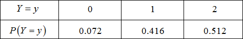